# A Case Study on Food Delivery Order Data

Plum Xu

April 2025

## Scenario

The client is a food delivery service provider centered around the Pittsburgh area. They have generated a dataset from all delivery orders placed through the service within the past year and are interested in understanding all the factors that impact the time to completion of an order from when it was placed. The client is additionally interested in possible methods for minimizing delivery time such that the overall volume of orders completed can be increased.

## Business Task

Which variables from the dataset have the greatest impact on delivery order completion time and what are the potential approaches to minimizing delivery time?

## Data Assessment

The data used for this case study was retrieved from a public Kaggle dataset posted by user Den_Kuznetz on December 22, 2024. According to its Kaggle description, “this dataset is designed for predicting food delivery times based on various influencing factors such as distance, weather, traffic conditions, and time of day.” Its usage in this case study is for an educational purpose and the data is not intended to be representative of any real-world company. For the purposes of this case study, this dataset is taken as internal data collected by the fictional client, subject to all credibility as well as biases entailed by such circumstances.

This dataset is structured as a single table, stored within a CSV file. The table is organized into long format with nine columns, listing each order made through the delivery service with a unique primary key. Each entry contains information about the conditions that each order was delivered under, including delivery distance, weather conditions, traffic conditions, time of day, delivery vehicle, order preparation time, courier experience level, and total delivery time. Regarding privacy and security, while the dataset does individually list unique orders made by users of the service, no user account information, user account details, transaction financial details, vendor details nor precise location data are kept within the dataset.

Table 1 — Preview of several rows of the original raw dataset.

| Order_ID | Distance_km | Weather | Traffic_Level | Time_of_Day | Vehicle_Type | Preparation_Time_min | Courier_Experience_yrs | Delivery_Time_min |
| --- | --- | --- | --- | --- | --- | --- | --- | --- |
| 522 | 7.93 | Windy | Low | Afternoon | Scooter | 12 | 1 | 43 |
| 738 | 16.42 | Clear | Medium | Evening | Bike | 20 | 2 | 84 |
| 741 | 9.52 | Foggy | Low | Night | Scooter | 28 | 1 | 59 |
| 661 | 7.44 | Rainy | Medium | Afternoon | Scooter | 5 | 1 | 37 |
| 412 | 19.03 | Clear | Low | Morning | Bike | 16 | 5 | 68 |
| 679 | 19.40 | Clear | Low | Evening | Scooter | 8 | 9 | 57 |

One possible limitation of the dataset is that, being internal data, the scope of analysis and potential insights are restricted by not being able to utilize equivalent data from competitor food delivery services as a point of comparison. For example, suppose that analysis on our dataset determined that courier experience level had the most significant impact on delivery time out of all the attributes. If analysis of delivery data from one or many competitors across the industry reflects this trend, we might be able to infer one takeaway, whereas if the analysis of competitor data reveals diverging trends, we are directed toward other questions and conclusions. That is not to suggest that sole analysis of internal data can serve no purpose, but rather to warn against extrapolation.

## Data Cleaning

After being imported into R, the delivery orders dataset was evaluated for its integrity before analysis could be performed. The dataset was filtered for rows with NULL values or blank text in any column, which were stored to a separate dataframe labeled `empty_values`. An additional dataframe, `non_empty_values`, was created by removing all rows with any blank entries from the original table.

The remaining unfiltered, i.e. non-empty, data was then examined to see if it fell within expected ranges or values. For all columns of numerical data, the maximum and minimum values found within each column were summarized within a table. This was to check for any mis-entries, such as negative values or accidental added or missing digits.

Table 2 — Minimum and maximum values of numerical variables calculated after removing blank data.

[output not shown]

For columns with text entries, the unique values found in each column were returned as separate vectors. This was to ensure that are no typos or mismatches in any of the text values, such as ‘Clear’ and ‘Claer’ being unintentionally classified as distinct weather conditions.

Range of weather values contained in dataset after filtering blank values:

```
## Windy, Clear, Foggy, Rainy, Snowy
```

Range of traffic level values contained in dataset after filtering blank values:

```
## Low, Medium, High
```

Range of time of day values contained in dataset after filtering blank values:

```
## Afternoon, Evening, Night, Morning
```

Range of vehicle type values contained in dataset after filtering blank values:”

```
## Scooter, Bike, Car
```

Examinining these ranges showed that no other character data aside from the blank text already filtered required further cleaning.

The `empty_values` table, created from filtering rows from the original dataset with a NULL value or blank text in any column, contained 117 rows out of the original 1000. This meant that 11.7% of the original dataset contained incomplete data of some kind, though this is not to be confused with 11.7% of the data being wholly missing. That being said, this was a proportion of data large enough such that dropping it entirely would have significantly impacted the sample of data available, and so a further exploration of the incomplete data was conducted.

In order to know where exactly the missing values were located, each column in the `empty_values` table was individually filtered again for NULL values or blank text, the number of which was counted and stored in a vector.

Another vector listing the name of each column, i.e. each type of data collected, was then created.

This allowed for a table to be created from the two vectors. In this table, one column listed each type of the data, and the other column listed the number of empty values found in that respective data’s column in the original dataset.

Table 3 — Number of missing values from original dataset for each variable.

| Data Type | No. of Missing Values |
| --- | --- |
| Order ID | 0 |
| Distance | 0 |
| Weather | 30 |
| Traffic Level | 30 |
| Time of Day | 30 |
| Vehicle Type | 0 |
| Prep. Time | 0 |
| Courier Exp. | 30 |
| Delivery Time | 0 |

The results of this exploration indicated that the missing data in the 117 rows were only limited to four columns, those being the `Weather`, `Traffic_Level`, `Time_of_Day`, and `Courier_Exp_yrs` columns. Critically, there were no missing data for order ID numbers, delivery distance, and delivery time data. As such, the decision was made to proceed with analysis retaining all rows from the original dataset, marking any missing values as ‘NA’.

## Data Analysis

Prior to analysis, several hypotheses were made as to which variables might be related to one another and which would have the greatest impact on delivery order completion time. It was hypothesized that delivery distance and courier vehicle type would see the strongest correlations with delivery time, as both of these variables form the base conditions to complete the order the means to complete it. It was additionally hypothesized that weather conditions, traffic level, courier experience, and order preparation time would all have minor impact on delivery completion time. Inclement weather and busy traffic could slow down or halt a courier on their route, while an experienced courier might be able to save time through knowledge of shortcuts or better navigation. Additionally, order preparation time is additional time a courier must wait before they can begin their final delivery. However, none of the aforementioned factors would change whether a courier must cover 5km or 20km, and whether they can do so on a bike or in a car. Finally, time of day was hypothesized to have the least impact on delivery time, with its potential impact being contingent on other variables. For example, visibility in poor weather conditions being reduced even further at night, or time of day and traffic level correlations reflecting rush hour patterns.

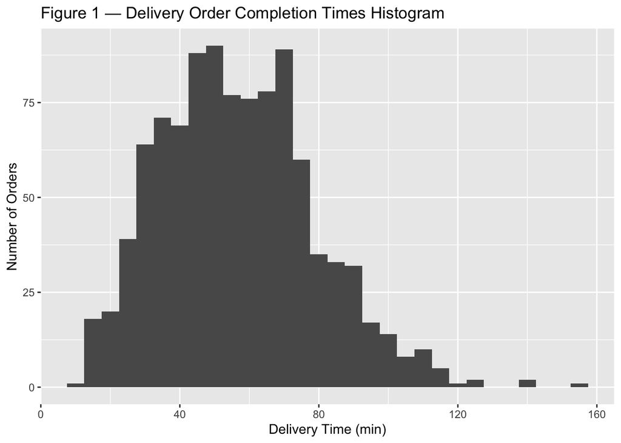

The first variables examined in the dataset were delivery distance and courier vehicle type. A scatterplot was generated with delivery distance in kilometers along the x-axis and delivery time in minutes along the y-axis, with each data point color-coded by the vehicle type the order was completed using. The resulting chart revealed a general linear relationship between delivery distance and delivery time, with the latter rising whenever the former did. Unexpectedly, however, vehicle type appeared to show no relationship with either variable. Data points across the chart adjacent to one another would show orders of near-identical distance completed in near-identical time in wholly different vehicles. Vehicle type effectively had no correlation with delivery distance and no impact on delivery time.

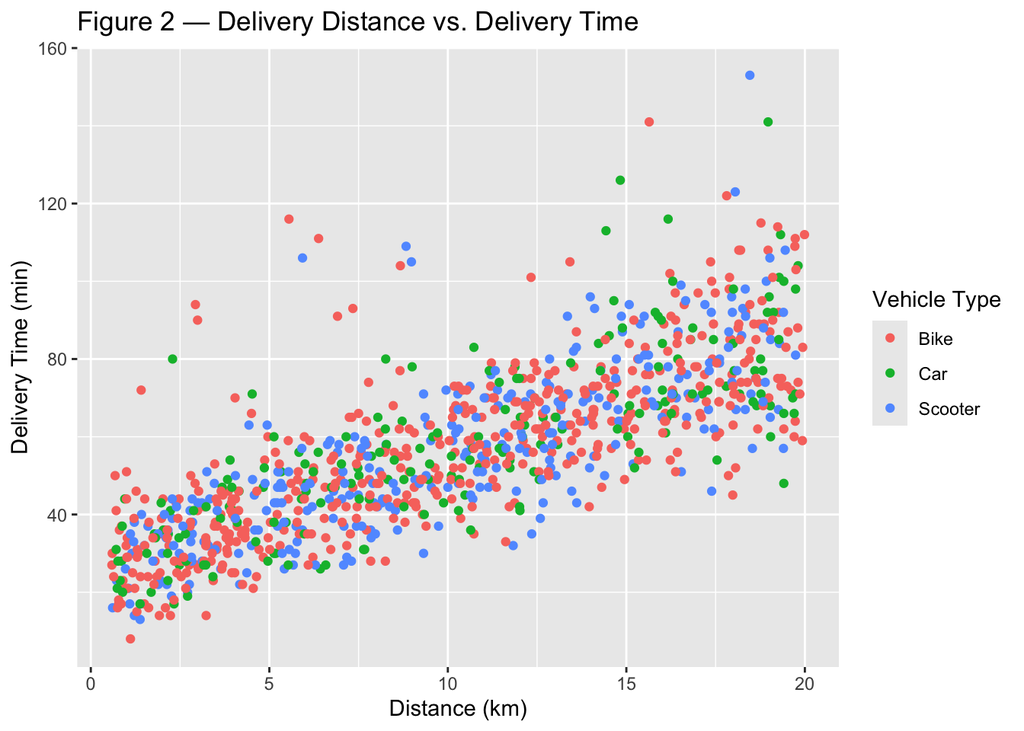

For the non-numerical variables in the dataset—weather, traffic level, time of day, and vehicle type—tables summarizing the average and median delivery times grouped by variable were generated. Additionally, while courier experience was technically measured and stored quantitatively as the number of years a courier had been working for the client, the data it reflected aligned less with other quantitative figures such as delivery distance and preparation time, and more as numerical labels of qualitative experience categories. Courier experience data was treated in the same fashion.

Table 4 — Average and median delivery times grouped by weather condition.

| Weather | Average Delivery Time (min) | Median Delivery Time (min) |
| --- | --- | --- |
| Clear | 53.08298 | 52.0 |
| Foggy | 59.46602 | 59.0 |
| N/A | 54.20000 | 53.5 |
| Rainy | 59.79412 | 57.5 |
| Snowy | 67.11340 | 66.0 |
| Windy | 55.45833 | 55.0 |

Table 5 — Average and median delivery times grouped by traffic level.

| Traffic Level | Average Delivery Time (min) | Median Delivery Time (min) |
| --- | --- | --- |
| Low | 52.88512 | 51.0 |
| Medium | 56.02051 | 53.5 |
| N/A | 62.06667 | 60.0 |
| High | 64.80711 | 65.0 |

Table 6 — Average and median delivery times grouped by time of day.

[output not shown]

Table 7 — Average and median delivery times grouped by courier vehicle type.

| Vehicle Type | Average Delivery Time (min) | Median Delivery Time (min) |
| --- | --- | --- |
| Scooter | 56.04636 | 54.5 |
| Bike | 56.57455 | 56.0 |
| Car | 58.20000 | 56.0 |

Table 8 — Average and median delivery times grouped by courier experience level.

| Courier Experience (Years) | Average Delivery Time (min) | Median Delivery Time (min) |
| --- | --- | --- |
| 0 | 60.23077 | 62.0 |
| 1 | 60.48598 | 57.0 |
| 2 | 54.37374 | 52.0 |
| 3 | 60.27500 | 58.0 |
| 4 | 59.59574 | 56.5 |
| 5 | 53.61111 | 52.0 |
| 6 | 56.54128 | 57.0 |
| 7 | 54.84615 | 50.0 |
| 8 | 53.99010 | 52.0 |
| 9 | 54.15741 | 51.0 |
| NA | 56.36667 | 53.5 |

The impact of the variables on delivery time was observed by comparing the difference in average delivery times across variables for each data type. Some variables were observed to have no impact on delivery time. The average time for each vehicle type, for example, was nearly identical, ranging between 56 and 58 minutes. On the other hand, the average delivery time in low traffic conditions was 53 minutes, while the average in high traffic conditions was 65 minutes, demonstrating the relationship between traffic level and delivery order completion time.

The final variable to be examined was order preparation time by the vendor. Knowing that delivery distance had already been observed to affect delivery time, as well as that order preparation time and delivery distance were independent variables from one another, it was hoped that distinguishing delivery distance within the preparation time plot would help highlight any impact the latter might have had. Having previously determined during the data-cleaning process that the maximum order distance in the dataset was 19.99km, delivery distance was grouped into four categories: orders with distances between 0km and 5km, distances greater than 5km up to 10km, greater than 10km up to 15km, and greater than 15km up to 20km. A new column was added to the dataset, grouping orders into these ranges. The range classifications are semi-arbitrary, serving to assist with data visualization rather than signify meaning beyond the distances contained within the range. With these groupings, the preparation time and delivery distance chart were subsetted into four separate charts grouped by distance category, where a linear relationship between the two initial variables was more easily observed.

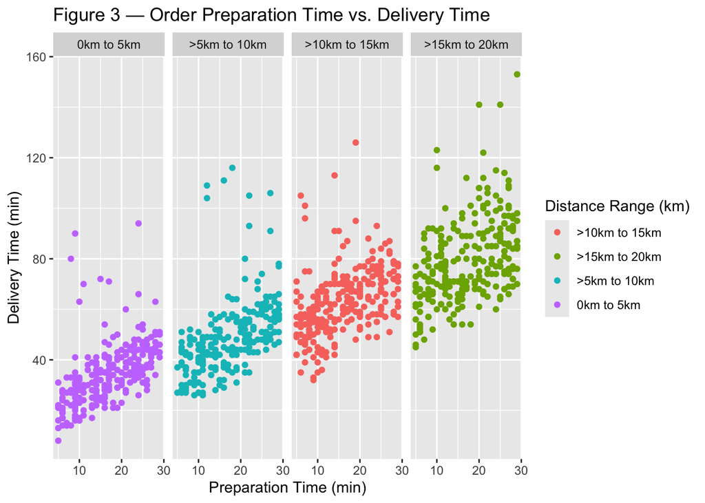

Having initially examined all variables within the dataset with respect to their relationship with delivery time, the variables were then grouped based on their apparent impact. *Delivery distance* appeared to have **significant impact** on delivery time; *weather*, *traffic level*, and *order preparation time* all appeared to have **minor impact** on delivery time; and *time of day*, *vehicle type*, *courier experience* all appeared to have **little to no impact** on delivery time.

## Findings

Returning to initial hypotheses, examination of the variables appeared to support the hypothesized relationship between delivery distance and delivery time. This comes as little surprise given that, if all other conditions remain consistent and a courier moves at generally the speed, it would take a greater amount of time for a courier to cover a longer distance. The purpose of exploring this dataset, however, was not strictly to determine whether delivery distance (among other variables) could impact delivery time, but rather in what ways its impact could be observed in the data, how its impact interacted with other factors, and what potential approaches would the data offer.

The same could have been said for vehicle type, though it came as a great surprise to observe its apparent lack of impact on delivery time. An expected result of comparing vehicle type with delivery distance and delivery time would have been that while delivery distance generally would have increased delivery time, deliveries covering a certain distance could be completed much sooner than using a car than they could using a scooter. As such, three separate trends might have been observable in the data, showing the general relationship between delivery distance and delivery time but easily distinguished by vehicle. Other expected impacts of vehicle type on the data include couriers with scooters and bikes being incentivized to only accept orders with shorter distance deliveries, and so orders over long distances may have been delivered more frequently by car.

The most likely cause for this unexpected result can be attributed to the creation of the dataset itself, having been posted by DEN_KUZNETZ on Kaggle for educational purposes, as opposed to having been based on real-world data collected by an organization. When generating the data, its author could have chosen not to or neglected to associate vehicle type data with any particular delivery time patterns. This explanation is useful for ruling out the possibility of errors made during analysis, and within the context of the business scenario, can be understood as indicating a possible source of error occurring somewhere within the client’s data collection, storage, or transfer processes.

Having determined the relative impact of the various factors from the available data on delivery order completion time and having addressed initial hypotheses laid out prior to beginning analysis, this report will move toward its findings and recommendations.

Given that delivery distance was found to have a significant impact on delivery time, further attention was paid to the quantity of orders made across distances, i.e. how many orders are shorter distance orders, longer distance orders, etc. This frequency distribution can be precisely represented using a histogram, but was found to be represented with better readability (for the purposes of this case study) using the distance ranges previously assigned to the dataset. From those ranges, a bar chart was generated, showing the number of orders between 0-5km, >5-10km, >10-15km, and >15-20km ranges. It can be observed from the chart that the number of orders within each distance range grouping is near equal, indicating that there are roughly as many deliveries between 0km and 5km as there are between 15km and 20km as there are between 5km and 10km and so on. The average delivery distance was calculated to be 10.06km.

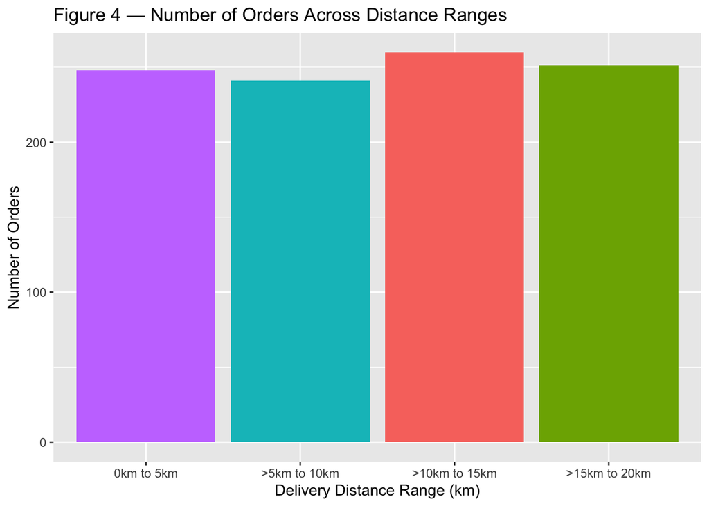

Regarding the three variables determined to have minor impact on delivery time, those being weather, traffic level, and order preparation time, the extent to which the client may influence these factors was considered. The distributed frequency of weather conditions and traffic levels within all orders was calculated, as well as the relative difference in average delivery time. Additionally, recommendations relating to order preparation time were considered. However, given that the impact of weather arises from environmental conditions and seasonal patterns, that traffic congestion patterns are a phenomenon resulting from urban density, and that order preparation is almost entirely dependent on vendors, the control that the client may exert over these variables is limited to secondary or tertiary control. If desired, an addendum containing further analysis and recommendations regarding minor impact factors can be provided upon request.

As such, we suggest the client reserve focus for the variable with the greatest observed impact on delivery time: delivery distance. We recommend the key priority of reducing the overall volume of longer distance orders and increasing the volume of shorter distance orders. To support this priority, we offer a number of potential solutions within the client’s control.

1. When using the food delivery service, distance from the user’s saved delivery address should be kept as a primary sorting across all categories.
2. When a user selects a vendor outside of a determined distance threshold, the interface can display similar vendors within a closer distance or closer locations of the same vendor, when applicable (without discrimination to individual vendors).
3. If a user habitually orders from particular vendors outside of distance threshold, offer one-time discounts for similar vendors within a closer distance or closer locations of the same vendor, when applicable.
4. Reduced delivery fees for orders under certain distance thresholds.

## Sources Cited

Den_Kuznetz. (2024). *Food Delivery Time Prediction*. Kaggle.  
https://www.kaggle.com/datasets/denkuznetz/food-delivery-time-prediction  
R Core Team (2025). *R: A Language and Environment for Statistical*  
*Computing*. R Foundation for Statistical Computing, Vienna, Austria.  
https://www.R-project.org/.  
Wickham H, Averick M, Bryan J, Chang W, McGowan LD, François R,  
Grolemund G, Hayes A, Henry L, Hester J, Kuhn M, Pedersen TL, Miller  
E, Bache SM, Müller K, Ooms J, Robinson D, Seidel DP, Spinu V,  
Takahashi K, Vaughan D, Wilke C, Woo K, Yutani H (2019). “Welcome to  
the tidyverse.” *Journal of Open Source Software*, *4*(43), 1686.  
doi:10.21105/joss.01686 https://doi.org/10.21105/joss.01686.  
Wickham H (2016). *ggplot2: Elegant Graphics for Data Analysis*.  
Springer-Verlag New York.  
Xie Y (2025). *knitr: A General-Purpose Package for Dynamic Report*  
*Generation in R*. R package version 1.50, https://yihui.org/knitr/.